# Taxonomy and evaluation of Computer Vision Tasks

## Miroslav Jiřík

# Tasks in Computer Vision

# Goal

- Make a list of all important computer vision tasks
- Learn how to evaluate the experiment

# Prerequisities

- Basic knowledge of Python - [Online course](http://pythonic.eu/fjfi/)
- Installed Python with computer vision packages [Anaconda distribution](https://www.anaconda.com/) or [Google Colab](https://colab.research.google.com/)
- [Google drive with code for practices](https://drive.google.com/drive/folders/1NsIsp5CIHDkE79bShjs-MhTX79CRFF8L?usp=share_link)
- This presentation sources: https://github.com/mjirik/usvp

[figure not shown]

What is the presented task?

- Classification
- Segmentation
- Tracking

# Image Classification

Image Classification (often referred to as Image Recognition) is the task of associating one (single-label classification) or more (multi-label classification) labels to a given image.

(definition by [Hmrishav Bandyopadhyay](https://www.v7labs.com/blog/image-classification-guide))

- Single-label Classification
  - Binar
  - General
- Multi-label Classification

## Binar classification

Email **✉**

- Spam
- Not Spam

## Binar classification - Example

[figure not shown]

[Image Source: Filipescu2021](https://onlinelibrary.wiley.com/doi/full/10.1111/srt.13045)

## Single-label Classification

Sometimes called also Multi-class Single-label Classification

[figure not shown]

## Multi-label Classification

[figure not shown]

[Madjarov2012: An extensive experimental comparison of methods for multi-label learning](https://doi.org/10.1016/j.patcog.2012.03.004)

[figure not shown]

See "Revisiting 3D ResNet for Video Recognition"

```python
import skimage
import skimage.io
import sklearn
import sklearn.metrics
import matplotlib.pyplot as plt
import seaborn as sn
import pandas as pd
import numpy as np
```

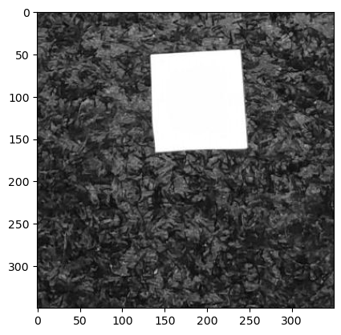

```python
i = 7
url = f"https://github.com/mjirik/ZDO/raw/master/objekty/binar_classification/{i:02d}.jpg"
im = skimage.io.imread(url, as_gray=True)
plt.imshow(im, cmap="gray")

# here is place for your code
# my_prediction = ...   # 0 for nothing, 1 for any object
```

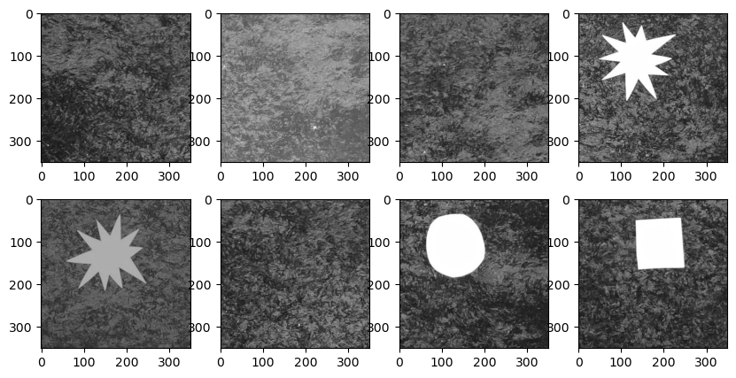

```python
fig, axs = plt.subplots(2,4, figsize=(10, 5))

y_pred = []
for i in range(8):
    url = f"https://github.com/mjirik/ZDO/raw/master/objekty/binar_classification/{i:02d}.jpg"
    im = skimage.io.imread(url, as_gray=True)
    # plt.figure() # uncomment if you want to see all images
    axs.flatten()[i].imshow(im, cmap="gray", clim=[0,1])

    # here is place for your code
    # my_prediction = ...  # 0 for nothing, 1 for any object

    my_prediction = 0
    y_pred.append(my_prediction)
plt.show()
```

# Ground Truth

"Ground truth" may be seen as a conceptual term relative to the knowledge of the truth concerning a specific question. It is the ideal expected result. [Lemoigne2006](https://link.springer.com/book/10.1007/978-1-4020-8752-3)

```python
y_true = [0,0,0,1,1,0,1,1]  # ground truth - manual annotation
y_pred = [0,1,0,1,0,0,1,1]  # machine prediction
```

```python
df = pd.read_csv("https://raw.githubusercontent.com/mjirik/ZDO/master/objekty/binar_classification/annotation.csv")
df[:5]
```

|  | filename | contain_object | object_type | coordinate_0 | coordinate_1 |
| --- | --- | --- | --- | --- | --- |
| 0 | 00.jpg | 0 | empty | NaN | NaN |
| 1 | 01.jpg | 0 | empty | NaN | NaN |
| 2 | 02.jpg | 0 | empty | NaN | NaN |
| 3 | 03.jpg | 1 | star | 108.0 | 140.0 |
| 4 | 04.jpg | 1 | star | 130.0 | 152.0 |

```python
y_pred = list(df['contain_object'])
```

# Now evaluate your results ...

You should be able to do it based on knowledge from course **KKY/APK** by **L. Šmídl** and **J. Švec**

## Evaluation of binary classifiers

- Precision
- Recall
- Sensitivity
- Specificity

## Confusion matrix

|  | Predicted Negative | Predicted Positive |
| --- | --- | --- |
| Actual Negative | True Negative | False Positive |
| Actual Positive | False Negative | True Positive |

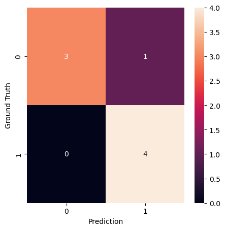

```python
y_test = [0,0,0,1,1,0,1,1]
y_pred = [0,1,0,1,1,0,1,1]

conf_matrix = sklearn.metrics.confusion_matrix(y_test, y_pred)
fig, ax = plt.subplots(figsize=(5, 5))
sn.heatmap(conf_matrix, annot=True)
plt.ylabel("Ground Truth")
plt.xlabel("Prediction")
```

# Accuracy

Accuracy is also used as a statistical measure of how well a binary classification test correctly identifies or excludes a condition. That is, the accuracy is the proportion of correct predictions (both true positives and true negatives) among the total number of cases examined. As such, it compares estimates of pre- and post-test probability. To make the context clear by the semantics, it is often referred to as the "Rand accuracy" or "Rand index". It is a parameter of the test.

$$ \textrm{Accuracy} = \frac{TP + TN}{TP + TN + FP + FN} $$

Sources: [Metz1978](https://www.sciencedirect.com/science/article/abs/pii/S0001299878800142?via%3Dihub) and [Wiki: Accuracy and Precision](https://en.wikipedia.org/wiki/Accuracy_and_precision)

$$ \textrm{Accuracy} = \frac{TP + TN}{TP + TN + FP + FN} $$

[figure not shown]

## Example - Accuracy

Try to implement...

First get the Ground Truth:

```python
df = pd.read_csv("https://github.com/mjirik/ZDO/raw/master/objekty/binar_classification/annotation.csv")
df[2:5]
```

|  | filename | contain_object | object_type | coordinate_0 | coordinate_1 |
| --- | --- | --- | --- | --- | --- |
| 2 | 02.jpg | 0 | empty | NaN | NaN |
| 3 | 03.jpg | 1 | star | 108.0 | 140.0 |
| 4 | 04.jpg | 1 | star | 130.0 | 152.0 |

```python
np.array(df["contain_object"])
```

```
array([0, 0, 0, 1, 1, 0, 1, 1, 1, 1, 1, 0, 0, 0, 1, 0, 0, 0, 1, 1, 0, 0,
       0, 1, 0, 0, 1, 0, 0, 0, 1, 0, 0, 1, 0, 0, 1, 0, 1, 1, 1, 0, 0, 0,
       1, 0, 0, 1, 1, 1, 1, 1, 0, 0, 0], dtype=int64)
```

## Precision, Recall=Sensitivity, Specificity

[figure not shown]

# Česká terminologie

České překlady pojmů se v praxi příliš nepoužívají. Nejblíže asi terminologie pro měření kvality přístrojové techniky ČSN ISO 5725-2.

**Přesnost** (anglicky accuracy, francouzsky exactitude, německy Genauigkeit) je souhrnný pojem charakterizující míru odchylek měření nebo pokusů od referenční hodnoty (tj. hodnoty, která je pokládána obecným jazykem za „správnou“). Přesnost zahrnuje pravdivost a preciznost (dříve správnost a shodnost).

**Pravdivost** (anglicky trueness, francouzsky justesse, německy Richtigkeit, podle starší verze ČSN ISO 5725-2:1997 správnost) znamená, že průměr velkého počtu měření nebo zkoušek se blíží skutečné hodnotě měřené veličiny (pravou nebo přijatou referenční hodnotou); jedná se o systematickou chybu, o míru statistického zkreslení.

**Preciznost** (anglicky precision, francouzsky fidélité, německy Präzision, podle ČSN starší verze ISO 5725-2:1997 též shodnost) se týká těsnosti shody mezi výsledky měření; jedná se o míru rozptylu.

Zdroje:

[ČSN ISO 5725-2: Přesnost (pravdivost a preciznost) metod a výsledků měření](https://eshop.normservis.cz/nahledy/view/csn/01/505452/505452_nahled.pdf)

[Wiki: Přesnost a preciznost](https://cs.wikipedia.org/wiki/P%C5%99esnost_a_preciznost)

## F1 Score

$$F1 Score = 2 \cdot \frac{Precision \cdot Recall}{Precision + Recall}$$

## Metrics Implementation

[Scikit-learn metrics docs](https://scikit-learn.org/stable/modules/model_evaluation.html)

```python
y_true = [0,0,0,1,1,0,1,1]
y_pred = [0,1,0,1,1,0,1,1]

print(f"Accuracy ={sklearn.metrics.accuracy_score(y_true, y_pred)}")
print(f"Precision={sklearn.metrics.precision_score(y_true, y_pred)}")
print(f"Recall   ={sklearn.metrics.recall_score(y_true, y_pred)}")
print(f"F1       ={sklearn.metrics.f1_score(y_true, y_pred)}")
```

```
Accuracy =0.875
Precision=0.8
Recall   =1.0
F1       =0.888888888888889
```

# ROC curve

ROC křivka (z anglického Receiver Operating Characteristic, operační charakteristika přijímače) je graf, který popisuje kvalitu binárního klasifikátoru v závislosti na nastavení jeho klasifikačního prahu.

[figure not shown]

Source: [scikit-learn docs](https://scikit-learn.org/stable/auto_examples/model_selection/plot_roc.html#sphx-glr-auto-examples-model-selection-plot-roc-py)

Čím tedy je ROC křivka zakřivenější ve směru vzhůru, tím víc klasifikační proměnná obsahuje informace o zařazení objektů a tím je její použití pro danou klasifikační úlohu vhodnější. Jako souhrnné hodnocení klasifikační schopnosti proměnné se proto často používá plocha pod ROC křivkou.

Binárním klasifikátorem se rozumí zařízení (nebo člověk) odhadující zařazení nějakých objektů nebo případů do dvou skupin, obecně označovaných jako pozitivní a negativní. Přitom se předpokládá, že objekty jsou charakterizovány nějakou vlastností (proměnnou) vyjádřenou číslem a že klasifikátor zařazuje do pozitivní skupiny právě ty, u kterých hodnota této proměnné přesáhne stanovený klasifikační práh (což je nějaké pevně dané číslo). Příkladem binárního klasifikátoru může být bankéř, který na základě kreditního skóre nějaké osoby rozhoduje, zda jí lze (pozitivní) nebo nelze (negativní) úspěšně poskytnout úvěr. Klasifikátor na základě takového postupu může buď objekt zařadit správně, anebo se může dopustit chyby; navíc záleží i na tom, zda případ je, nebo není ve skutečnosti pozitivní. Lze tak rozlišit čtyři případy: 1. skutečný pozitivní (true positive, jejich počet se označuje TP; odpovídá situaci, kdy bankéř poskytne úvěr a klient ho řádně splatí), 2. skutečný negativní (true negative, TN; bankéř odmítne klienta, který by úvěr nesplatil), 3. falešný pozitivní čili falešný poplach (false positive, FP; poskytnutí úvěru klientovi, který peníze bance nevrátí) a 4. falešný negativní (false negative, FN; klient nedostane úvěr, i když by ho řádně splácel).

[Wikipedia: ROC křivka](https://cs.wikipedia.org/wiki/ROC_k%C5%99ivka)

## References

[Wikipedia: ROC křivka](https://cs.wikipedia.org/wiki/ROC_k%C5%99ivka)

[Wikiskripta: ROC křivka](https://www.wikiskripta.eu/w/ROC_k%C5%99ivka)

[Fawcett, Tom (2006). "An Introduction to ROC Analysis" (PDF). Pattern Recognition Letters. 27 (8): 861–874. doi:10.1016/j.patrec.2005.10.010.](http://people.inf.elte.hu/kiss/11dwhdm/roc.pdf)

## Evaluation of multi-class classification

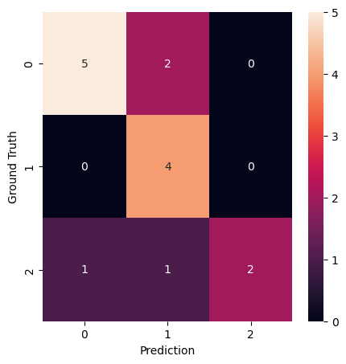

```python
y_true = [0,0,0,1,1,0,2,0,0,0,1,1,2,2,2]
y_pred = [0,1,0,1,1,0,1,0,1,0,1,1,2,0,2]

conf_matrix = sklearn.metrics.confusion_matrix(y_true, y_pred)
fig, ax = plt.subplots(figsize=(5, 5))
sn.heatmap(conf_matrix, annot=True)
plt.ylabel("Ground Truth")
plt.xlabel("Prediction")
```

```python
y_true = [0,0,0,1,1,0,2,0,0,0,1,1,2,2,2]
y_pred = [0,1,0,1,1,0,1,0,1,0,1,1,2,0,2]

print(f"Accuracy ={sklearn.metrics.accuracy_score(y_true, y_pred)}")
print(f"Precision={sklearn.metrics.precision_score(y_true, y_pred, average=None)}")
print(f"Recall   ={sklearn.metrics.recall_score(y_true, y_pred, average=None)}")
print(f"F1       ={sklearn.metrics.f1_score(y_true, y_pred, average=None)}")
```

```
Accuracy =0.7333333333333333
Precision=[0.83333333 0.57142857 1.        ]
Recall   =[0.71428571 1.         0.5       ]
F1       =[0.76923077 0.72727273 0.66666667]
```

## References

- [Accuracy, precision, recall](https://www.mage.ai/blog/definitive-guide-to-accuracy-precision-recall-for-product-developers)
- [Revisiting 3D ResNet for Video Recognition](https://paperswithcode.com/paper/revisiting-3d-resnets-for-video-recognition)

# Datasets for classification

## MNIST dataset

The MNIST database of handwritten digits, available from this page, has a training set of 60,000 examples, and a test set of 10,000 examples. It is a subset of a larger set available from NIST.

[figure not shown]

### References

- Kussul, Ernst; Baidyk, Tatiana (2004). "Improved method of handwritten digit recognition tested on MNIST database". Image and Vision Computing. 22 (12): 971–981. doi:10.1016/j.imavis.2004.03.008 .

## Skin cancer dataset HAM10000

[figure not shown]

Examples of images downloaded from the HAM10000 dataset. These images are publicly available through the International Skin Imaging Collaboration (ISIC) archive and represent more than 95% of all pigmented lesions encountered during clinical practice (Tschandl P 2018). (A) Melanocytic nevus; (B) Bening keratosis; (C) Vascular lesion; (D) Dermatofibroma; (E) Intraepithelial carcinoma; (F) Basal cell carcinoma; (G) Melanoma. Legends inside each image represents clinical data such as age, sex and localization associated to the image. F: female; M: male; LE: lower extremity; B: back; H: Hand; T: trunk.

Source: [Deep Neural Frameworks Improve the Accuracy of General Practitioners in the Classification of Pigmented Skin Lesions](https://doi.org/10.3390/diagnostics10110969)

# ImageNet

The most highly-used subset of ImageNet is the ImageNet Large Scale Visual Recognition Challenge (ILSVRC) 2012-2017 image classification and localization dataset. This dataset spans 1000 object classes and contains 1,281,167 training images, 50,000 validation images and 100,000 test images. This subset is available on Kaggle.

[figure not shown]

On 30 September 2012, a convolutional neural network (CNN) called AlexNet achieved a top-5 error of 15.3% in the ImageNet 2012 Challenge, more than 10.8 percentage points lower than that of the runner up. This was made feasible due to the use of graphics processing units (GPUs) during training, an essential ingredient of the deep learning revolution. According to The Economist, "Suddenly people started to pay attention, not just within the AI community but across the technology industry as a whole."

## Classification - Important algorithms - AlexNet

Krizhevsky, Alex, Ilya Sutskever, and Geoffrey E. Hinton. ["Imagenet classification with deep convolutional neural networks."](https://proceedings.neurips.cc/paper/2012/hash/c399862d3b9d6b76c8436e924a68c45b-Abstract.html) Advances in neural information processing systems 25 (2012).([PDF](https://dl.acm.org/doi/pdf/10.1145/3065386))

[figure not shown]

## AlexNet

[figure not shown]

## References

- J. Deng, W. Dong, R. Socher, L. -J. Li, Kai Li and Li Fei-Fei, "ImageNet: A large-scale hierarchical image database," 2009 IEEE Conference on Computer Vision and Pattern Recognition, 2009, pp. 248-255, doi: 10.1109/CVPR.2009.5206848.
- [Wikipedia: ImageNet](https://en.wikipedia.org/wiki/ImageNet)
- Krizhevsky, Alex; Sutskever, Ilya; Hinton, Geoffrey E. (June 2017). "ImageNet classification with deep convolutional neural networks" (PDF). Communications of the ACM. 60 (6): 84–90. [doi:10.1145/3065386](https://doi.org/10.1145%2F3065386). ISSN 0001-0782. S2CID 195908774. Retrieved 24 May 2017.
- [Ye Tengqi, "Visual Object Detection from Lifelogs using Visual Non-lifelog Data"](http://dx.doi.org/10.13140/RG.2.2.18463.46248)

# End to end training

Image source: ["Geirhos2020: Shortcut Learning in Deep Neural Networks"](https://doi.org/10.1038/s42256-020-00257-z)

[figure not shown]

## Try the classification by end-to-end learning

[Teachable Machine](https://teachablemachine.withgoogle.com/)

# Deep learning vs traditional CV

[figure not shown]

Taken from ["Deep Learning vs. Traditional Computer Vision"](http://dx.doi.org/10.1007/978-3-030-17795-9_10)

[figure not shown]

Taken from ["Deep Learning vs. Traditional Computer Vision"](http://dx.doi.org/10.1007/978-3-030-17795-9_10)

# Let's try the neural net

- [MNIST classification](https://drive.google.com/drive/folders/1NsIsp5CIHDkE79bShjs-MhTX79CRFF8L?usp=sharing)
- [PyTorch MNIST classification on Metacentrum](https://github.com/mjirik/tutorials/tree/main/metacentrum/pytorch_quickstart)

## More examples

- https://www.tensorflow.org/tutorials/images/classification
- https://www.tensorflow.org/hub/tutorials/tf2_image_retraining

# Classification

Input:

- Image

Output:

- Single-label Classification - One label per image selected from predefined group
- Multi-label Classification - Multiple labels selected from predefined group

Evaluation:

- Accuracy
- Precision
- Recall (Sensitivity)
- F1
- ROC

# Regression

Regression is a process of finding the correlations between dependent and independent variables. It helps in predicting the continuous variables such as prediction of Market Trends, prediction of House prices, etc.

The task of the Regression algorithm is to find the mapping function to map the input variable(x) to the continuous output variable(y).

[Source](https://www.javatpoint.com/regression-vs-classification-in-machine-learning)

[figure not shown]

## Regression vs Classification

[figure not shown]

Hlavní rozdíl mezi regresními a klasifikačními algoritmy je ten, že regresní algoritmy se používají k predikci spojitých hodnot, jako je cena, plat, věk atd., a klasifikační algoritmy se používají k predikci/klasifikaci diskrétních hodnot, jako je muž nebo žena, pravda nebo nepravda, Spam or Not Spam atd.

Source: [https://www.javatpoint.com/](https://www.javatpoint.com/regression-vs-classification-in-machine-learning)

| Regresní algoritmus | Algoritmus klasifikace |
| --- | --- |
| Při regresi musí nabývat výstupní proměnná spojitých hodnot. | Při klasifikaci musí být výstupní proměnná diskrétní hodnota. |
| Úkolem regresního algoritmu je mapovat vstupní hodnotu (x) na spojitou výstupní proměnnou (y). | Úkolem klasifikačního algoritmu je mapovat vstupní hodnotu (x) na diskrétní výstupní proměnnou (y). |
| Regresní algoritmy se používají se spojitými daty. | Klasifikační algoritmy se používají s diskrétními daty. |
| Při regresi se snažíme najít nejvhodnější linii, která dokáže přesněji předpovědět výstup. | Při klasifikaci se snažíme najít rozhodovací hranici, která může rozdělit datovou sadu do různých tříd. |
| Regresní algoritmy lze použít k řešení regresních problémů, jako je předpověď počasí, předpověď ceny domu atd. | Klasifikační algoritmy lze použít k řešení problémů klasifikace, jako je identifikace spamových e-mailů, rozpoznávání řeči, identifikace rakovinných buněk atd. |
| Regresní algoritmus lze dále rozdělit na lineární a nelineární regresi. | Algoritmy klasifikace lze rozdělit na binární klasifikátor a klasifikátor s více třídami. |

Source: [https://www.javatpoint.com/](https://www.javatpoint.com/regression-vs-classification-in-machine-learning)

## Regression evaluation

### Mean Square Error

$$ \text{MSE}(y, \hat{y}) = \frac{1}{n_\text{samples}} \sum_{i=0}^{n_\text{samples} - 1} (y_i - \hat{y}_i)^2. $$

### Mean Absolute Error

$$ \text{MAE}(y, \hat{y}) = \frac{1}{n_{\text{samples}}} \sum_{i=0}^{n_{\text{samples}}-1} \left| y_i - \hat{y}_i \right|. $$

### Max Error

$$ \text{Max Error}(y, \hat{y}) = max(| y_i - \hat{y}_i |) $$

```python
y_true = [2,3,1,1,3,1,5]
y_pred = [2,3,2,1,2,2,2]

print(f"MSE ={sklearn.metrics.mean_squared_error(y_true, y_pred)}")
print(f"MAE ={sklearn.metrics.mean_absolute_error(y_true, y_pred)}")
print(f"MaxE={sklearn.metrics.max_error(y_true, y_pred)}")
```

```
MSE =1.7142857142857142
MAE =0.8571428571428571
MaxE=3
```

## What if...

### Is it possible to estimate temperature with classification?

# Regression - conclusion

Input:

- Image

Output:

- Continuous (float) number or vector

Metrics:

- Mean Square Error
- Mean Absolute Error
- Max Error

# Filtration

In signal processing, a filter is a device or process that removes some unwanted components or features from a signal.

Filtering is a class of signal processing, the defining feature of filters being the complete or partial suppression of some aspect of the signal. Most often, this means removing some frequencies or frequency bands. However, filters do not exclusively act in the frequency domain; especially in the field of image processing many other targets for filtering exist.

[figure not shown]

Noise reduction

[T. Vogelsong, J. Tower, T. Senko, P. Levine, J. Janesick, J. Zhu, D. Zhang, G. van der Wal, and M. Piacentino "Low-light NV-CMOS image sensors for day/night imaging", Proc. SPIE 8713, Airborne Intelligence, Surveillance, Reconnaissance (ISR) Systems and Applications X, 87130F (31 May 2013); https://doi.org/10.1117/12.2016396](http://dx.doi.org/10.1117/12.2016396)

## Target dependent

[figure not shown]

## Filtration - Conclusion

Input:

- Image

Output:

- Image with supressed unwanted components of the image and emhasized target components of the image

# Data is all you need

# How to split dataset

## Training Dataset

Training Dataset: The sample of data used to fit the model. The actual dataset that we use to train the model (weights and biases in the case of a Neural Network). The model sees and learns from this data.

## Validation Dataset

Validation Dataset: The sample of data used to provide an unbiased evaluation of a model fit on the training dataset while tuning model hyperparameters. The evaluation becomes more biased as skill on the validation dataset is incorporated into the model configuration.

The validation set is used to evaluate a given model, but this is for frequent evaluation.

## Test Dataset

Test Dataset: The sample of data used to provide an unbiased evaluation of a final model fit on the training dataset.

The Test dataset provides the gold standard used to evaluate the model. It is only used once a model is completely trained(using the train and validation sets).

[figure not shown]

```python
import numpy as np
from sklearn.model_selection import train_test_split
```

```python
X, y = np.arange(10).reshape((5, 2)), range(5)
X,y
```

```
(array([[0, 1],
        [2, 3],
        [4, 5],
        [6, 7],
        [8, 9]]),
 range(0, 5))
```

```python
X_train, X_test, y_train, y_test = train_test_split(X, y, test_size=0.33, random_state=42)
X_train, X_test, y_train, y_test
```

```
(array([[4, 5],
        [0, 1],
        [6, 7]]),
 array([[2, 3],
        [8, 9]]),
 [2, 0, 3],
 [1, 4])
```

## References

- [Train, validation and test sets](https://towardsdatascience.com/train-validation-and-test-sets-72cb40cba9e7)
- [scikit-learn](https://scikit-learn.org/stable/modules/generated/sklearn.model_selection.train_test_split.html)

## COCO

- Object segmentation
- Recognition in context
- Superpixel stuff segmentation
- 330K images (>200K labeled)
- 1.5 million object instances
- 80 object categories
- 91 stuff categories
- 5 captions per image
- 250,000 people with keypoints

[figure not shown]

Source: Microsoft COCO: Common Objects in Context

## COCO json

COCO format JSON file consists of five sections providing information for an entire dataset. For more information, see COCO format.

- info – general information about the dataset.
- licenses – license information for the images in the dataset.
- images – a list of images in the dataset.
- annotations – a list of annotations (including bounding boxes) that are present in all images in the dataset.
- categories – a list of label categories.

```
{
    "info": info,
    "images": [image],
    "annotations": [annotation],
    "licenses": [license],
}
info{
    "year": int,
    "version": str,
    "description": str,
    "contributor": str,
    "url": str,
    "date_created": datetime,
}
image{
    "id": int,
    "width": int,
    "height": int,
    "file_name": str,
    "license": int,
    "flickr_url": str,
    "coco_url": str,
    "date_captured": datetime,
}
license{
    "id": int,
    "name": str,
    "url": str,
}
```

```
{
    "info": {
        "description": "COCO 2017 Dataset",
        "url": "http://cocodataset.org",
        "version": "1.0","year": 2017,
        "contributor": "COCO Consortium",
        "date_created": "2017/09/01"
    },
    "licenses": [
        {"url": "http://creativecommons.org/licenses/by/2.0/","id": 4,"name": "Attribution License"}
    ],
    "images": [
        {"id": 242287, "license": 4,
         "coco_url": "http://images.cocodataset.org/val2017/xxxxxxxxxxxx.jpg",
         "flickr_url": "http://farm3.staticflickr.com/2626/xxxxxxxxxxxx.jpg",
         "width": 426, "height": 640, "file_name": "xxxxxxxxx.jpg",
         "date_captured": "2013-11-15 02:41:42"},
        {"id": 245915, "license": 4,
         "coco_url": "http://images.cocodataset.org/val2017/nnnnnnnnnnnn.jpg",
         "flickr_url": "http://farm1.staticflickr.com/88/xxxxxxxxxxxx.jpg",
         "width": 640, "height": 480, "file_name": "nnnnnnnnnn.jpg",
         "date_captured": "2013-11-18 02:53:27"}
    ],
    "annotations": [
        {"id": 125686, "category_id": 0, "iscrowd": 0,
         "segmentation": [[164.81, 417.51,......167.55, 410.64]],
         "image_id": 242287, "area": 42061.80340000001,
         "bbox": [19.23, 383.18, 314.5, 244.46]},
        {"id": 1409619, "category_id": 0, "iscrowd": 0,
         "segmentation": [[376.81, 238.8,........382.74, 241.17]],
         "image_id": 245915, "area": 3556.2197000000015,
         "bbox": [399, 251, 155, 101]},
        {"id": 1410165, "category_id": 1, "iscrowd": 0,
         "segmentation": [[486.34, 239.01,..........495.95, 244.39]],
         "image_id": 245915, "area": 1775.8932499999994,
         "bbox": [86, 65, 220, 334]}
    ],
    "categories": [
        {"supercategory": "speaker","id": 0,"name": "echo"},
        {"supercategory": "speaker","id": 1,"name": "echo dot"}
    ]
}
```

## Resources

- [Paper: "Microsoft COCO: Common Objects in Context"](https://link.springer.com/content/pdf/10.1007%2F978-3-319-10602-1_48.pdf)
- [COCO json format](https://cocodataset.org/#format-data)
- [Transforming COCO datasets](https://docs.aws.amazon.com/rekognition/latest/customlabels-dg/md-transform-coco.html)

# Annotation tools

## CVAT

[figure not shown]

## Via annotation tool

[via annotation tool](https://www.robots.ox.ac.uk/~vgg/software/via/)

[figure not shown]

# Metacentrum

[Beginners Guide](https://wiki.metacentrum.cz/wiki/Beginners_guide)

[Personal view](https://metavo.metacentrum.cz/pbsmon2/person)

[Tensorflow quickstart on Metacentrum](https://github.com/mjirik/tutorials/blob/main/metacentrum/tensorflow_quickstart/metacentrum_tensorflow.md)

[Jupyter for MetaCentrum Users](https://wiki.metacentrum.cz/wiki/Jupyter_for_MetaCentrum_users)

# Localization

Single object localization

[figure not shown]

Image source: [Object Localization using Keras by Roy Ganz](https://medium.com/analytics-vidhya/object-localization-using-keras-d78d6810d0be)

Input: Image

Output: Bounding box of single object

# Detection

[figure not shown]

Image source: [Evolution of object detection networks](https://cogneethi.com/evodn/object_detection_intro/)

## Detection - Evaluation

[figure not shown]

### Intersection over Union (Jaccard index)

$$ J(A,B) = {{|A \cap B|}\over{|A \cup B|}} = {{|A \cap B|}\over{|A| + |B| - |A \cap B|}} $$

[figure not shown]

### Dice coefficient

$$ DICE = \frac{2\left|{S_{g}^{1}} \cap {S_{t}^{1}}\right|}{\left|{S_{g}^{1}}\right| + \left|{S_{t}^{1}}\right|} = \frac{2 TP}{2 TP + FP + FN} $$

$$ IoU=\frac{\left|{S_{g}^{1}} \cap {S_{t}^{1}}\right|}{\left|{S_{g}^{1}} \cup {S_{t}^{1}}\right|}=\frac{2\left|{S_{g}^{1}} \cap {S_{t}^{1}}\right|}{2\left(\left|{S_{g}^{1}}\right|+\left|{S_{t}^{1}}\right|- \left|{S_{g}^{1}} \cap {S_{t}^{1}}\right|\right)} =\frac{DICE}{2-DICE} $$

## Try detection

[Object Detectioin Inference on TF and TF Hub](https://colab.research.google.com/drive/1t274wS4_dE62nBrfyHltO0dqr_Cc_5wr?usp=share_link)

### More examples

[Detectron2 in Google Colab](https://colab.research.google.com/github/Tony607/detectron2_instance_segmentation_demo/blob/master/Detectron2_custom_coco_data_segmentation.ipynb#scrollTo=MWknKqWTWIw9)

[Detectron2 on MetaCentrum](https://github.com/mjirik/tutorials/tree/main/metacentrum/detectron2_quickstart))

[Detetron2 on Windows](https://github.com/mjirik/tutorials/tree/main/detectron_windows)

### References

- [Jaccard, Paul (February 1912). "THE DISTRIBUTION OF THE FLORA IN THE ALPINE ZONE.1". New Phytologist. 11 (2): 37–50. doi:10.1111/j.1469-8137.1912.tb05611.x. ISSN 0028-646X.](https://doi.org/10.1111%2Fj.1469-8137.1912.tb05611.x)
- [Wikipedia: Jaccard index](https://en.wikipedia.org/wiki/Jaccard_index)
- [sklearn doc](https://scikit-learn.org/stable/modules/generated/sklearn.metrics.jaccard_score.html#sklearn.metrics.jaccard_score)
- [Dice LR. Measures of the amount of ecologic association between species. Ecology. 1945; 26(3):297–302.](https://doi.org/10.2307%2F1932409)
- [Taha, A.A., Hanbury, A. Metrics for evaluating 3D medical image segmentation: analysis, selection, and tool. BMC Med Imaging 15, 29 (2015). https://doi.org/10.1186/s12880-015-0068-x](https://doi.org/10.1186/s12880-015-0068-x)

## Detection - Conclusion

Input:

- Image

Output:

- Bounding box and class label for each object

Metrics:

- Intersection over Union (Jaccard index)
- Dice coefficient

# Tracking

Input:

- Video

Output:

- Tracks defined by coordinates of single point or bounding box in time.

```python
YouTubeVideo(id="re5VNG4PJ3M")
```

[video not shown]

## Tracking - Evaluation

[figure not shown]

## Tracking - Evaluation

Point tracking

- Mean Square Error
- Hausdorff distance (MaxD)

Bounding box tracking:

- Multiple Object Tracking Accuracy (MOTA)

$$ MOTA = 1 - \frac{\sum_t{FN_t + FP_t + IDSt}}{\sum_t{GT_t}} $$

where $FN_t$ is the number of false negatives (missed targets), $FP_t$ the number of false positives (ghost trajectories), $IDS_t$ the number of identity switches at time t. A target is considered missed if the IoU with the ground truth is inferior to a given threshold. (Note that the MOTA can be negative.)

## References

- [Song et al.: Performance Evaluation Metrics and Approaches for Target Tracking: A Survey](https://doi.org/10.3390/s22030793)
- [Cindy Tring Sridykhan: A tour of Video Object Tracking — Part III: Multiple Object Tracking](https://medium.com/@cindy.trinh.sridykhan/a-tour-of-video-object-tracking-part-iii-multiple-object-tracking-5e3a15ae0a7c)

# Segmentation

VSTUP:

- INTENZITNÍ OBRAZ

VÝSTUP:

- OBRAZ ROZČLENĚNÝ NA ČÁSTI, KTERÉ MAJÍ SOUVISLOST S OBJEKTY REÁLNÉHO SVÉTA

Kompletní segmentace

- vytvořené oblasti jednoznačně korespondují s objekty ve vstupním obraze
- obecně nezbytná spolupráce s vyšší úrovní zpracování, využití znalostí o řešeném problému
- v případě, kdy je obraz tvořen kontrastními objekty na pozadí konstantního jasu – dobré výsledky

kompletní segmentace i na nižší úrovni zpracování

- Příklad: text, krevní buňky, počítání šroubků

Částečná segmentace

- vytvořené oblasti jsou homogenní vzhledem k určitým zvoleným vlastnostem (jas, barva, textura,

apod.)

- oblasti se obecně mohou překrývat
- je třeba aplikovat další postupy na vyšší úrovni zpracování
- Příklad: scéna s polem a lesem při pohledu z okna – po segmentaci neodpovídá objektu jedna oblast

Pro segmentaci se využívá znalost o řešeném problému čím více, tím lépe

```python
YouTubeVideo(id="_bp5LTQ9D0M", start=int(timedelta(hours=0, minutes=0, seconds=33).total_seconds()))
```

[video not shown]

[YouTube link](https://youtu.be/_bp5LTQ9D0M?t=33)

## Semantic Segmentation

[figure not shown]

Source: [Jeong, J.; Yoon, T.S.; Park, J.B. Towards a Meaningful 3D Map Using a 3D Lidar and a Camera. Sensors 2018, 18, 2571.](https://doi.org/10.3390/s18082571)

[figure not shown]

Source: [An overview of semantic image segmentation by Jeremy Jordan](https://www.jeremyjordan.me/semantic-segmentation/) and [YouTube](https://www.youtube.com/watch?v=ATlcEDSPWXY)

### Semantic segmentation: U-Net

[figure not shown]

[Ronneberger, O., P.Fischer, & Brox, T. (2015). U-Net: Convolutional Networks for Biomedical Image Segmentation. Medical Image Computing and Computer-Assisted Intervention (MICCAI), 9351, 234–241. http://lmb.informatik.uni-freiburg.de/Publications/2015/RFB15a](https://doi.org/10.1007/978-3-319-24574-4_28)

## Instance Segmentation

[figure not shown]

## Instance Segmentation

Input:

- Image

Output:

- Per pixel segmenation of each individual object of each class

## Segmentation - evaluation

Per pixel (voxel)

- Intesection over Union (Jaccard index) $$ IoU = \frac{\left|{A} \cap {B}\right|}{\left|{A} \cup {B}\right|} $$
- Dice coefficient $$ DICE = \frac{2\left|{A} \cap {B}\right|}{\left|{A}\right| + \left|{B}\right|} = \frac{2 TP}{2 TP + FP + FN} $$
- Pixel Accuracy $$ \textrm{Accuracy} = \frac{TP + TN}{TP + TN + FP + FN} $$ Pixel Accuracy can sometimes provide misleading results when the class representation is small within the image, as the measure will be biased in mainly reporting how well you identify negative case (ie. where the class is not present).

[figure not shown]

- Hausdorf distance $$ d(\mathcal{S}_1, \mathcal{S}_2) = max_{p \in \mathcal{S}_1}(d(p, \mathcal{S}_2)) \label{eq:05} $$
- Max distance $$ \text{MaxD} = max(d(\mathcal{S}_1, \mathcal{S}_2), d(\mathcal{S}_2, \mathcal{S}_1)) \label{eq:04} $$
- Average Symmetric Surface Distance $$ \text{ASD}=\frac1{{\left|\text{S}{\left(\text{GT}\right)}\right|}+{\left|{\left.\text{S}\left(\text{MS}\right.\right)}\right|}}{\left(\sum_{\left.{\text{S}}_\text{gt}\in\text{S}\left(\text{GT}\right.\right)}\text{d}{\left({\text{S}}_\text{gt},\text{S}{\left(\text{MS}\right)}\right)}+\sum_{\left.{\text{S}}_\text{ms}\in\text{S}\left(\text{MS}\right.\right)}\text{d}{\left({\text{S}}_\text{ms},\text{S}{\left(\text{GT}\right)}\right)}\right)} $$ Average of all the distances from points on the boundary of MS to the boundary of the GT, and vice versa

[figure not shown]

## Segmentation datasets

- COCO

## Liver Segmentation 3D-IRCADb-01

[figure not shown]

[IRCADb](https://www.ircad.fr/research/data-sets/liver-segmentation-3d-ircadb-01/)

# Let's try segmentation

[U-Net: Oxford-IIIT Pet Dataset](https://colab.research.google.com/drive/1_tCZ98_1v38fRzrrvoqEic1-TljgmzQs?usp=sharing)

[U-Net: Liver segmentation](https://drive.google.com/file/d/1yHYUFzvnFsZ6i6avO7NFiVzxUOLoJBLv/view?usp=sharing)

### References

- [Yeghiazaryan and Voiculescu: Family of boundary overlap metrics for the evaluation of medical image segmentation](https://www.ncbi.nlm.nih.gov/pmc/articles/PMC5817231/)
- [Jeremy Jordan: Evaluating image segmentation models](https://www.jeremyjordan.me/evaluating-image-segmentation-models/)

## Segmentation - Conclusion

Input:

- Image

Output:

- Labeled Image

Metrics:

- Intersection over Union
- Jaccard index
- Pixel Accuracy (problematic)
- Hausdorf distance / Max distance
- Average Symmetric Surface Distance

# Style Transfer

Image source: [machinelearningmastery.com](https://machinelearningmastery.com/wp-content/uploads/2018/12/Example-of-Neural-Style-Transfer-from-Famous-Artworks-to-a-Photograph.png)

[figure not shown]

[Application of Deep Learning for Computer Vision](https://machinelearningmastery.com/wp-content/uploads/2018/12/Examples-of-Photo-Colorization.png)

[figure not shown]

Taken from "Unpaired Image-to-Image Translation using Cycle-Consistent Adversarial Networks"

[figure not shown]

Taken from "10 Interesting Computer Vision Tasks"

## References

- [A Neural Algorithm of Artistic Style](https://arxiv.org/abs/1508.06576)
- [Application of Deep Learning for Computer Vision](https://machinelearningmastery.com/applications-of-deep-learning-for-computer-vision/)
- [Colorful Image Colorization](https://arxiv.org/abs/1603.08511)
- [Unpaired Image-to-Image Translation using Cycle-Consistent Adversarial Networks](https://arxiv.org/abs/1703.10593)
- [10 Interesting Computer Vision Tasks](https://towardsdev.com/10-interesting-computer-vision-tasks-3e5437a14668)

# Style Transfer

Input:

- Image

Output:

- Image transfered in different style

# Image Reconstruction

Image reconstruction and image inpainting is the task of filling in missing or corrupt parts of an image.

[figure not shown]

Taken from ["Image Inpainting for Irregular Holes Using Partial Convolutions"](https://machinelearningmastery.com/wp-content/uploads/2018/12/Example-of-Photo-Inpainting.png)

## References

- [Image Inpainting for Irregular Holes Using Partial Convolutions](https://arxiv.org/abs/1804.07723)

# Image Super Resolution

[figure not shown]

Taken from ["Photo-Realistic Single Image Super-Resolution Using a Generative Adversarial Network"](https://machinelearningmastery.com/wp-content/uploads/2018/12/Example-of-the-results-from-Different-Super-Resolution-Techniques.png)

## References

- [Photo-Realistic Single Image Super-Resolution Using a Generative Adversarial Network](https://arxiv.org/abs/1609.04802)

# Image Synthesis

[figure not shown]

Example of Generated Bathrooms. Taken from ["Unsupervised Representation Learning with Deep Convolutional Generative Adversarial Networks"](https://machinelearningmastery.com/wp-content/uploads/2018/12/Example-of-Generated-Bathrooms.png)

## References

- [Unsupervised Representation Learning with Deep Convolutional Generative Adversarial Networks](https://arxiv.org/abs/1511.06434)

# Pose estimation

[figure not shown]

Taken from "Deep Sports Pose"

[figure not shown]

# References

- [MMPose](https://github.com/open-mmlab/mmpose)
- [Deep Sports Pose](https://www.uni-augsburg.de/en/fakultaet/fai/informatik/prof/mmc/research/research_projects/deep_sports_pose/)

# Conclustion

## Computer Vsision tasks

- Classification
- Filtration
- Localization
- Detection
- Tracking
- Style Transfer
- Segmentation
- Landmark detection
- Image restauration

## Experiment evaluation

- Mean Square Error
- Accuracy
- Precision
- Sensitivity
- Intersection over Union

## Important algorithms and architectures

- AlexNet, ResNet (Classification)
- U-Net (Segmentation)
- FasterRCNN (Detection)